# EDA

```python
import pandas as pd
import numpy as np
import matplotlib.pyplot as plt
import seaborn as sns
```

```python
merged_df = pd.read_csv('merged_df_v2.csv')
```

```python
merged_df = pd.read_csv('merged_df_v3.csv')
```

```python
merged_df
```

|  | Stock | Year | Revenue | Revenue Growth | Operating Income | Net Income | Net Income Ratio | Gross Profit | Gross Profit Ratio | Operating Expenses | ... | expected_revenuegrowth | revenuegrowth_match | expected_costofrevenue | costofrevenue_match | expected_operatingincome | operatingincome_match | expected_operatingexpenses | operatingexpenses_match | expected_depreciationamortization | depreciationamortization_match |
| --- | --- | --- | --- | --- | --- | --- | --- | --- | --- | --- | --- | --- | --- | --- | --- | --- | --- | --- | --- | --- | --- |
| 0 | AAFRW | 2000 | 1.103142e+09 | 0.000000 | 2.918478e+08 | 2.915345e+08 | 0.264276 | 6.296658e+08 | 0.570793 | 3.378181e+08 | ... | 0.000000 | False | 4.734762e+08 | True | 2.918478e+08 | True | 3.378181e+08 | True | 7821411.0 | True |
| 1 | AAFRW | 2002 | 9.519782e+08 | 22.890035 | 1.890946e+08 | 1.887653e+08 | 0.198287 | 3.978879e+08 | 0.417959 | 2.087934e+08 | ... | 22.890035 | False | 5.540903e+08 | True | 1.890946e+08 | True | 2.087934e+08 | True | 4493034.0 | True |
| 2 | AAFRW | 2003 | 1.283757e+09 | 0.348515 | 4.323393e+08 | 4.314507e+08 | 0.336084 | 7.196193e+08 | 0.560557 | 2.872800e+08 | ... | 0.348515 | False | 5.641375e+08 | True | 4.323393e+08 | True | 2.872800e+08 | True | 2228554.0 | True |
| 3 | AAFRW | 2004 | 1.503795e+08 | -0.882860 | 1.974637e+07 | 1.931370e+07 | 0.128433 | 6.864248e+07 | 0.456462 | 4.889611e+07 | ... | -0.882860 | False | 8.173707e+07 | True | 1.974637e+07 | True | 4.889611e+07 | True | 5271247.0 | True |
| 4 | AAFRW | 2005 | 2.193423e+09 | 13.585912 | 4.247539e+07 | 4.176383e+07 | 0.019040 | 7.088561e+08 | 0.323173 | 6.663807e+08 | ... | 13.585912 | False | 1.484567e+09 | True | 4.247539e+07 | True | 6.663807e+08 | True | 9412834.0 | True |
| ... | ... | ... | ... | ... | ... | ... | ... | ... | ... | ... | ... | ... | ... | ... | ... | ... | ... | ... | ... | ... | ... |
| 99679 | ZTMXAP | 2001 | 1.360600e+09 | NaN | NaN | NaN | NaN | NaN | NaN | NaN | ... | NaN | NaN | NaN | NaN | NaN | NaN | NaN | NaN | NaN | NaN |
| 99680 | ZTMXAP | 2003 | 2.576235e+08 | NaN | NaN | NaN | NaN | NaN | NaN | NaN | ... | NaN | NaN | NaN | NaN | NaN | NaN | NaN | NaN | NaN | NaN |
| 99681 | ZTMXAP | 2005 | 4.837877e+08 | NaN | NaN | NaN | NaN | NaN | NaN | NaN | ... | NaN | NaN | NaN | NaN | NaN | NaN | NaN | NaN | NaN | NaN |
| 99682 | ZTMXAP | 2006 | 7.930096e+08 | NaN | NaN | NaN | NaN | NaN | NaN | NaN | ... | NaN | NaN | NaN | NaN | NaN | NaN | NaN | NaN | NaN | NaN |
| 99683 | ZTMXAP | 2008 | 1.808217e+09 | NaN | NaN | NaN | NaN | NaN | NaN | NaN | ... | NaN | NaN | NaN | NaN | NaN | NaN | NaN | NaN | NaN | NaN |

99684 rows × 36 columns

### Drop the helper columns

```python
helper_columns = [col for col in merged_df.columns if 'expected' in col or 'match' in col]
```

```python
merged_df = merged_df.drop(columns=(helper_columns))
```

```python
merged_df
```

|  | Stock | Year | Revenue | Revenue Growth | Operating Income | Net Income | Net Income Ratio | Gross Profit | Gross Profit Ratio | Operating Expenses | Cost of Revenue | EBITDA | Interest Expense | Depreciation & Amortization |
| --- | --- | --- | --- | --- | --- | --- | --- | --- | --- | --- | --- | --- | --- | --- |
| 0 | AAFRW | 2000 | 1.103142e+09 | 0.000000 | 2.918478e+08 | 2.915345e+08 | 0.264276 | 6.296658e+08 | 0.570793 | 3.378181e+08 | 4.734762e+08 | 2.996692e+08 | 313268.0 | 7821411.0 |
| 1 | AAFRW | 2002 | 9.519782e+08 | 22.890035 | 1.890946e+08 | 1.887653e+08 | 0.198287 | 3.978879e+08 | 0.417959 | 2.087934e+08 | 5.540903e+08 | 1.935876e+08 | 329216.0 | 4493034.0 |
| 2 | AAFRW | 2003 | 1.283757e+09 | 0.348515 | 4.323393e+08 | 4.314507e+08 | 0.336084 | 7.196193e+08 | 0.560557 | 2.872800e+08 | 5.641375e+08 | 4.345678e+08 | 888596.0 | 2228554.0 |
| 3 | AAFRW | 2004 | 1.503795e+08 | -0.882860 | 1.974637e+07 | 1.931370e+07 | 0.128433 | 6.864248e+07 | 0.456462 | 4.889611e+07 | 8.173707e+07 | 2.501762e+07 | 432671.0 | 5271247.0 |
| 4 | AAFRW | 2005 | 2.193423e+09 | 13.585912 | 4.247539e+07 | 4.176383e+07 | 0.019040 | 7.088561e+08 | 0.323173 | 6.663807e+08 | 1.484567e+09 | 5.188822e+07 | 711551.0 | 9412834.0 |
| ... | ... | ... | ... | ... | ... | ... | ... | ... | ... | ... | ... | ... | ... | ... |
| 99679 | ZTMXAP | 2001 | 1.360600e+09 | NaN | NaN | NaN | NaN | NaN | NaN | NaN | NaN | NaN | NaN | NaN |
| 99680 | ZTMXAP | 2003 | 2.576235e+08 | NaN | NaN | NaN | NaN | NaN | NaN | NaN | NaN | NaN | NaN | NaN |
| 99681 | ZTMXAP | 2005 | 4.837877e+08 | NaN | NaN | NaN | NaN | NaN | NaN | NaN | NaN | NaN | NaN | NaN |
| 99682 | ZTMXAP | 2006 | 7.930096e+08 | NaN | NaN | NaN | NaN | NaN | NaN | NaN | NaN | NaN | NaN | NaN |
| 99683 | ZTMXAP | 2008 | 1.808217e+09 | NaN | NaN | NaN | NaN | NaN | NaN | NaN | NaN | NaN | NaN | NaN |

99684 rows × 14 columns

# 1. Checking Outliers & Frequency Distribution

### Check for outliers

```python
merged_df.dtypes
```

```
Stock                           object
Year                             int64
Revenue                        float64
Revenue Growth                 float64
Operating Income               float64
Net Income                     float64
Net Income Ratio               float64
Gross Profit                   float64
Gross Profit Ratio             float64
Operating Expenses             float64
Cost of Revenue                float64
EBITDA                         float64
Interest Expense               float64
Depreciation & Amortization    float64
dtype: object
```

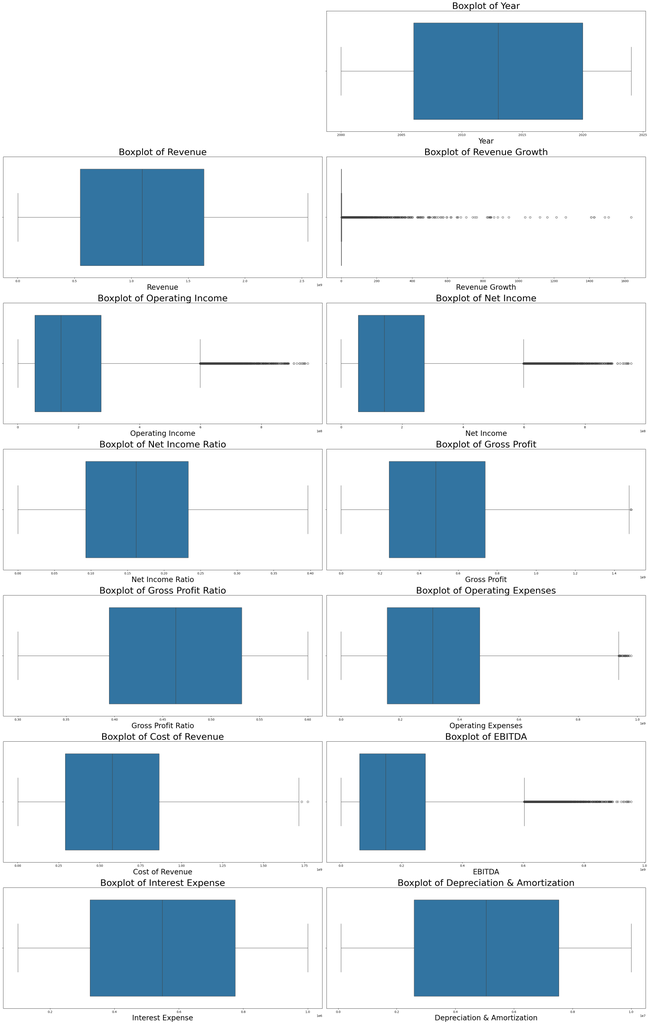

```python
# Generate box plots of each column, as long as it is not an object

plt.figure(figsize=(30, 60))
for i, col in enumerate(merged_df.columns):
    if merged_df[col].dtype != 'object':
        ax = plt.subplot(9, 2, i + 1)
        sns.boxplot(data=merged_df, x=col, ax=ax)
        ax.set_xlabel(col, fontsize=24)
        ax.set_title(f"Boxplot of {col}", fontsize=30)
        plt.xlabel(col)
plt.tight_layout()
plt.show()
```

```python
for i, col in enumerate(merged_df.columns):
    if merged_df[col].dtype != 'object':
        Q1 = merged_df[col].quantile(0.25)
        Q3 = merged_df[col].quantile(0.75)
        IQR = Q3 - Q1
        # Define outlier thresholds
        lower_bound = Q1 - 1.5 * IQR
        upper_bound = Q3 + 1.5 * IQR

        # Identify outliers
        outliers = merged_df[(merged_df[col] < lower_bound) | (merged_df[col] > upper_bound)]

        print("Outliers:")
        print(outliers[[col]])

        # Check the percentage of outliers
        outlier_percentage = len(outliers) / len(merged_df) * 100
        print(f"Percentage of Outliers in {col}: {outlier_percentage:.2f}%")

        # Insert a separatar after each column
        print("xxxxxxxxxxxxxxxxxxxxxxxxxxxxxxxxxxxxxxxxxxxxxxxxxxxxxxxxxxxxxxxxxxxxx\n")
```

```
Outliers:
Empty DataFrame
Columns: [Year]
Index: []
Percentage of Outliers in Year: 0.00%
xxxxxxxxxxxxxxxxxxxxxxxxxxxxxxxxxxxxxxxxxxxxxxxxxxxxxxxxxxxxxxxxxxxxx

Outliers:
Empty DataFrame
Columns: [Revenue]
Index: []
Percentage of Outliers in Revenue: 0.00%
xxxxxxxxxxxxxxxxxxxxxxxxxxxxxxxxxxxxxxxxxxxxxxxxxxxxxxxxxxxxxxxxxxxxx

Outliers:
       Revenue Growth
1           22.890035
4           13.585912
10           5.392040
13           3.062269
16           4.296705
...               ...
98466        8.238096
98476        7.404359
98480        5.762097
98486        4.988482
98489        3.047464

[12089 rows x 1 columns]
Percentage of Outliers in Revenue Growth: 12.13%
xxxxxxxxxxxxxxxxxxxxxxxxxxxxxxxxxxxxxxxxxxxxxxxxxxxxxxxxxxxxxxxxxxxxx

Outliers:
       Operating Income
70         6.584504e+08
150        7.952840e+08
157        6.030593e+08
180        5.999801e+08
190        6.145877e+08
...                 ...
```

[output cut: 110 more lines]

```
xxxxxxxxxxxxxxxxxxxxxxxxxxxxxxxxxxxxxxxxxxxxxxxxxxxxxxxxxxxxxxxxxxxxx

Outliers:
Empty DataFrame
Columns: [Interest Expense]
Index: []
Percentage of Outliers in Interest Expense: 0.00%
xxxxxxxxxxxxxxxxxxxxxxxxxxxxxxxxxxxxxxxxxxxxxxxxxxxxxxxxxxxxxxxxxxxxx

Outliers:
Empty DataFrame
Columns: [Depreciation & Amortization]
Index: []
Percentage of Outliers in Depreciation & Amortization: 0.00%
xxxxxxxxxxxxxxxxxxxxxxxxxxxxxxxxxxxxxxxxxxxxxxxxxxxxxxxxxxxxxxxxxxxxx
```

```python
# Further reading into Revenue Growth outliers
revenue_growth_Q1 = merged_df['Revenue Growth'].quantile(0.25)
revenue_growth_Q3 = merged_df['Revenue Growth'].quantile(0.75)
revenue_growth_IQR = revenue_growth_Q3 - revenue_growth_Q1
revenue_growth_lower_bound = revenue_growth_Q1 - 1.5 * revenue_growth_IQR
revenue_growth_upper_bound = revenue_growth_Q3 + 1.5 * revenue_growth_IQR

# Identify outliers
revenue_growth_outliers = merged_df[
    (merged_df['Revenue Growth'] < revenue_growth_lower_bound) |
    (merged_df['Revenue Growth'] > revenue_growth_upper_bound)
]['Revenue Growth']

# Calculate statistics for the outliers
if not revenue_growth_outliers.empty:
    min_outlier = revenue_growth_outliers.min()
    mean_outlier = revenue_growth_outliers.mean()
    max_outlier = revenue_growth_outliers.max()

    print(f"Min Outlier: {min_outlier:.2f}")
    print(f"Mean Outlier: {mean_outlier:.2f}")
    print(f"Max Outlier: {max_outlier:.2f}")
else:
    print("No outliers detected in Revenue Growth.")
```

```
Min Outlier: 2.86
Mean Outlier: 21.77
Max Outlier: 1635.02
```

**Outlier Distribution**:

Most columns have no outliers which indicate data consistency. Operating Income, Net Income, Operating Expenses and EBITDA show small percentages of outliers and are likely natural variations of financial metrics. This also indicates that the operational metrics are stable and reliable.

**Revenue Growth**:

12.13% of the data in Revenue Growth are identified as outliers. Revenue growth rates can have high variability as a result of market conditions and company expansions.

merged_df is also sorted by Stock & Year to show the year-on-year growth in Revenue more clearly.

Hence, this does not reflect an issue with the data or affect the consistency of the other metrics in the dataset.

### Frequency Distribution of Metrics

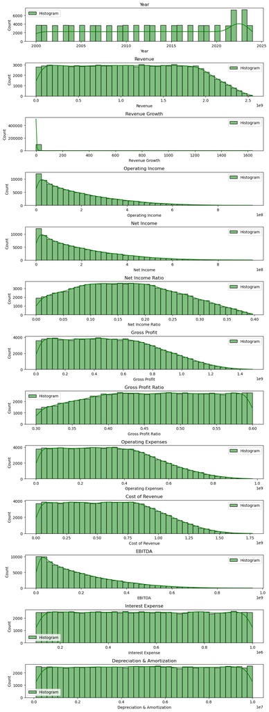

```python
# For each column, create a histogram of counts to check distribution of skew
plt.figure(figsize=(10, len(merged_df.columns) * 2))

# Iterate over numeric columns
for i, col in enumerate(merged_df.columns):
    if merged_df[col].dtype != 'object':
        plt.subplot(len(merged_df.columns), 1, i + 1)
        sns.histplot(
            merged_df[col],
            kde=True,
            color='g',
            bins=40,
            label='Histogram'
        )
        plt.title(col)
        plt.legend()

plt.tight_layout()
plt.show()
```

**Operating Income, Net Income & EBITDA**:

The distribution is heavily skewed to the right. Most values are concentrated to the lower end with fewer data points reaching into the higher ranges. This could indicate that most companies have lower profits while only a few companies are extremely profitable.

**Revenue**:

Revenue is evenly spread out from the low to middle range, but have low counts on the extreme right. Only a few companies generated exceptionally high revenue.

**Gross Profit Ratio & Net Income Ratio**:

**Operating Expenses & Cost of Revenue**:

Operating Expenses (selling, general and administrative expenses) & Cost of Revenue (direct cost of goods/services) cluster in the low to middle range, but skew to the right afterwards.

Most companies in this dataset operate with moderate expenses, which also aligns with the fact that they generate lower revenues.

The right skew in both expense types suggest that only a few companies have exceptionally high expenses, which can be due to highly large-scale and complex businesses with high direct and operating costs.

# 2. Analyzing Revenue

### Total Revenue and Revenue Growth Over Time

```python
merged_df.columns
```

```
Index(['Stock', 'Year', 'Revenue', 'Revenue Growth', 'Operating Income',
       'Net Income', 'Net Income Ratio', 'Gross Profit', 'Gross Profit Ratio',
       'Operating Expenses', 'Cost of Revenue', 'EBITDA', 'Interest Expense',
       'Depreciation & Amortization'],
      dtype='object')
```

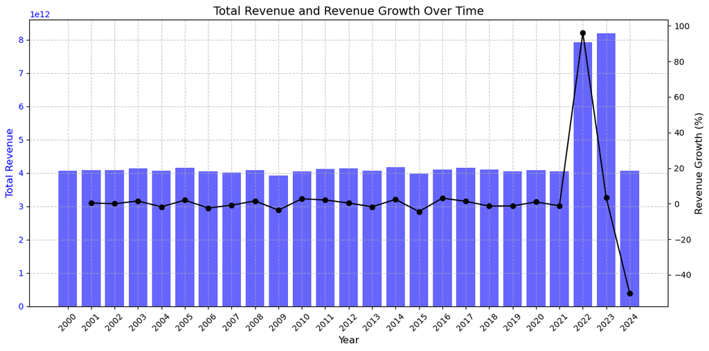

```python
# Aggregate total revenue by 'Year'
summary = merged_df.groupby('Year').agg({
    'Revenue': 'sum'
}).reset_index()

# Calculate revenue growth as the percentage change from the previous year
summary['Revenue Growth'] = summary['Revenue'].pct_change() * 100

# Create a combo chart: Revenue as bars and Revenue Growth as a line
fig, ax1 = plt.subplots(figsize=(12, 6))

# Plot Revenue as bars
ax1.bar(summary['Year'], summary['Revenue'], color='blue', label='Total Revenue', alpha=0.6)
ax1.set_xlabel('Year', fontsize=12)
ax1.set_ylabel('Total Revenue', fontsize=12, color='blue')
ax1.tick_params(axis='y', labelcolor='blue')

# Create a second y-axis for Revenue Growth
ax2 = ax1.twinx()
ax2.plot(summary['Year'], summary['Revenue Growth'], marker='o', color='black', label='Revenue Growth (%)')
ax2.set_ylabel('Revenue Growth (%)', fontsize=12, color='black')
ax2.tick_params(axis='y', labelcolor='black')

# Title and grid
plt.title('Total Revenue and Revenue Growth Over Time', fontsize=14)
ax1.grid(True, linestyle='--', alpha=0.7)

# Label all years on the x-axis
ax1.set_xticks(summary['Year'])
ax1.set_xticklabels(summary['Year'], rotation=45, fontsize=10)

# Display the chart
plt.tight_layout()
plt.show()
```

### Histogram of Revenue by Year (2020-2024)

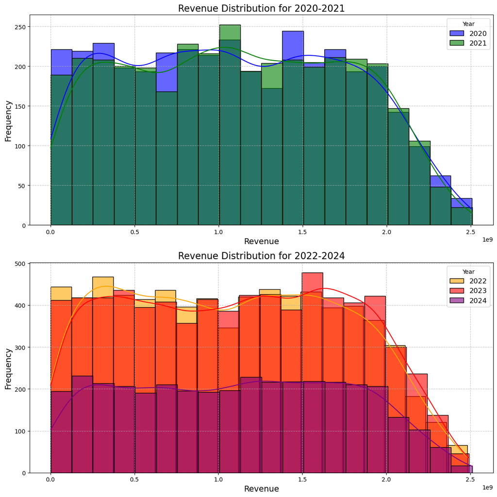

```python
# Filter data for 2020 to 2024
df_filtered_2020_2024 = merged_df[merged_df['Year'].isin([2020, 2021, 2022, 2023, 2024])]

# Create a figure with two subplots (one for 2020-2021 and one for 2022-2024)
fig, (ax1, ax2) = plt.subplots(2, 1, figsize=(12, 12))  # Adjusted for bigger charts and vertical layout

# Plot histograms for 2020 and 2021 on ax1
sns.histplot(df_filtered_2020_2024[df_filtered_2020_2024['Year'] == 2020]['Revenue'], kde=True, bins=20, alpha=0.6, label='2020', color='blue', ax=ax1)
sns.histplot(df_filtered_2020_2024[df_filtered_2020_2024['Year'] == 2021]['Revenue'], kde=True, bins=20, alpha=0.6, label='2021', color='green', ax=ax1)

# Set titles and labels for 2020-2021
ax1.set_title('Revenue Distribution for 2020-2021', fontsize=16)
ax1.set_xlabel('Revenue', fontsize=14)
ax1.set_ylabel('Frequency', fontsize=14)
ax1.legend(title='Year', fontsize=12)
ax1.grid(True, linestyle='--', alpha=0.7)

# Plot histograms for 2022, 2023, and 2024 on ax2
sns.histplot(df_filtered_2020_2024[df_filtered_2020_2024['Year'] == 2022]['Revenue'], kde=True, bins=20, alpha=0.6, label='2022', color='orange', ax=ax2)
sns.histplot(df_filtered_2020_2024[df_filtered_2020_2024['Year'] == 2023]['Revenue'], kde=True, bins=20, alpha=0.6, label='2023', color='red', ax=ax2)
sns.histplot(df_filtered_2020_2024[df_filtered_2020_2024['Year'] == 2024]['Revenue'], kde=True, bins=20, alpha=0.6, label='2024', color='purple', ax=ax2)

# Set titles and labels for 2022-2024
ax2.set_title('Revenue Distribution for 2022-2024', fontsize=16)
ax2.set_xlabel('Revenue', fontsize=14)
ax2.set_ylabel('Frequency', fontsize=14)
ax2.legend(title='Year', fontsize=12)
ax2.grid(True, linestyle='--', alpha=0.7)

# Display the charts
plt.tight_layout()
plt.show()
```

Revenue frequencies were around 2 times more in 2022-2023 than 2020-2021 & 2024.

### Top 5 Companies by Revenue (2020-2024)

We are also interested to observe how the Top 5 companies with the highest revenue performed from 2020 to 2024.

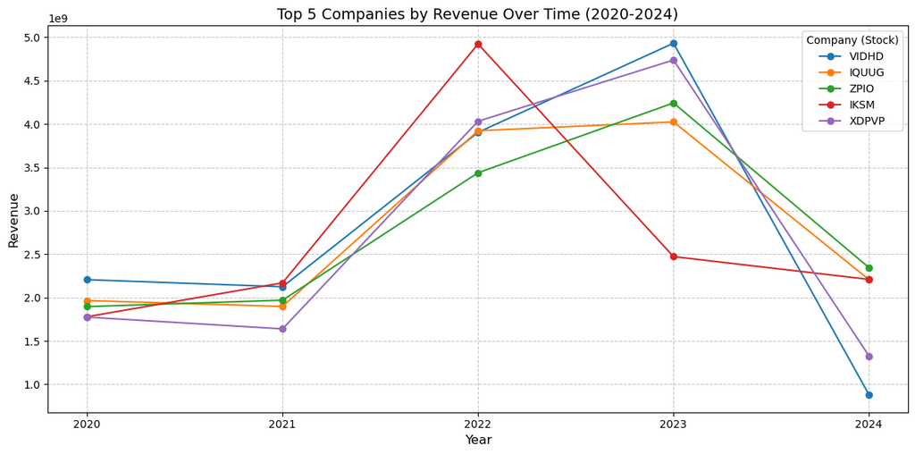

```python
# Aggregate total revenue by 'Year' and 'Stock'
df_revenue = merged_df.groupby(['Year', 'Stock']).agg({
    'Revenue': 'sum'
}).reset_index()

# Filter data for the years 2020-2024
df_revenue_filtered = df_revenue[df_revenue['Year'].between(2020, 2024)]

# Aggregate total revenue by company (Stock) across all years to find the top 5
top_5_revenue = df_revenue_filtered.groupby('Stock')['Revenue'].sum().nlargest(5).index

# Filter the data for the top 5 companies
df_top_5_revenue = df_revenue_filtered[df_revenue_filtered['Stock'].isin(top_5_revenue)]

# Create a line chart for top 5 companies by Revenue over time (2020-2024)
plt.figure(figsize=(12, 6))

for stock in top_5_revenue:
    company_data = df_top_5_revenue[df_top_5_revenue['Stock'] == stock]
    plt.plot(company_data['Year'], company_data['Revenue'], marker='o', label=stock)

# Title and labels
plt.title('Top 5 Companies by Revenue Over Time (2020-2024)', fontsize=14)
plt.xlabel('Year', fontsize=12)
plt.ylabel('Revenue', fontsize=12)
plt.legend(title='Company (Stock)', fontsize=10)
plt.grid(True, linestyle='--', alpha=0.7)
plt.xticks(ticks=range(2020, 2025))  # Label years 2020-2024 on x-axis
plt.tight_layout()
plt.show()
```

**IKSM Performance**: IKSM reached its peak revenue in 2022 but experienced a decline during 2023 and 2024. This suggests potential challenges, such as product or service issues or increased discounts that may have impacted revenue.

**Peer Companies**: The companies VIDHD, IQUUG, ZPIO, and XDPVP outperformed IKSM in revenue in 2023. However, by 2024, only IQUUG and ZPIO continued to generate revenue comparable to IKSM. This trend hints that these five companies might belong to the same industry, as IKSM's contrasting performance from 2022 to 2023 is notable compared to the other companies.

The period of 2022-2023 was likely marked by a strong economy, with many businesses expanding their operations. This broader economic growth may have influenced revenue trends across companies.

### Relationship between Net Income Ratio vs Gross Profit Ratio

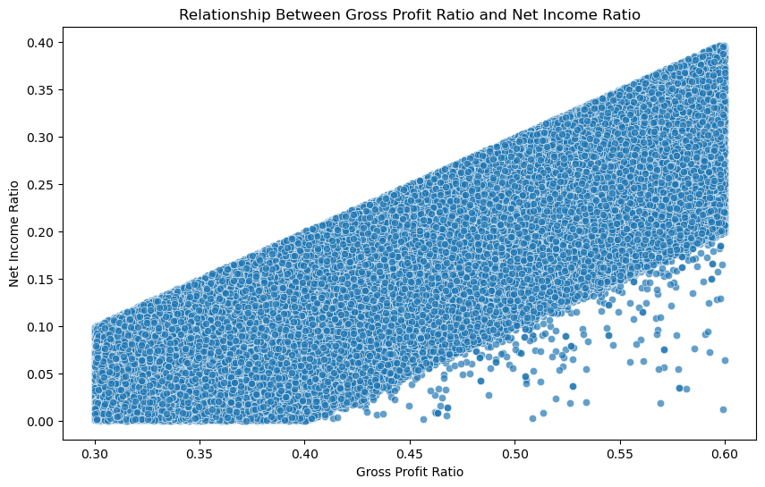

```python
plt.figure(figsize=(10, 6))
sns.scatterplot(data=merged_df, x='Gross Profit Ratio', y='Net Income Ratio', alpha=0.7)
plt.title('Relationship Between Gross Profit Ratio and Net Income Ratio')
plt.xlabel('Gross Profit Ratio')
plt.ylabel('Net Income Ratio')
plt.show()
```

**Correlation**: Gross Profit Ratio and Net Income Ratio show a strong positive corelation where Net Income increases and Gross Profit increases.

A small group of points at the bottom right show that Net Income does not increase as proportionately when Gross Profit increases.

This can indicate that expenses could be higher for these data points which could have resulted in lower Net Income.

# 3. Analyzing Profit

### Adding Operating Expense Ratio & Operating Income Ratio

```python
merged_df['Operating Expense Ratio'] = merged_df['Operating Expenses'] / merged_df['Revenue']
```

```python
merged_df['Operating Income Ratio'] = merged_df['Operating Income'] / merged_df['Revenue']
```

```python
merged_df['Operating Expense Ratio']
```

```
0        0.306233
1        0.219326
2        0.223781
3        0.325151
4        0.303809
           ...
99679         NaN
99680         NaN
99681         NaN
99682         NaN
99683         NaN
Name: Operating Expense Ratio, Length: 99684, dtype: float64
```

```python
merged_df['Operating Income Ratio']
```

```
0        0.264560
1        0.198633
2        0.336777
3        0.131310
4        0.019365
           ...
99679         NaN
99680         NaN
99681         NaN
99682         NaN
99683         NaN
Name: Operating Income Ratio, Length: 99684, dtype: float64
```

### Profit Growth over Time (including Operating Expense Ratio)

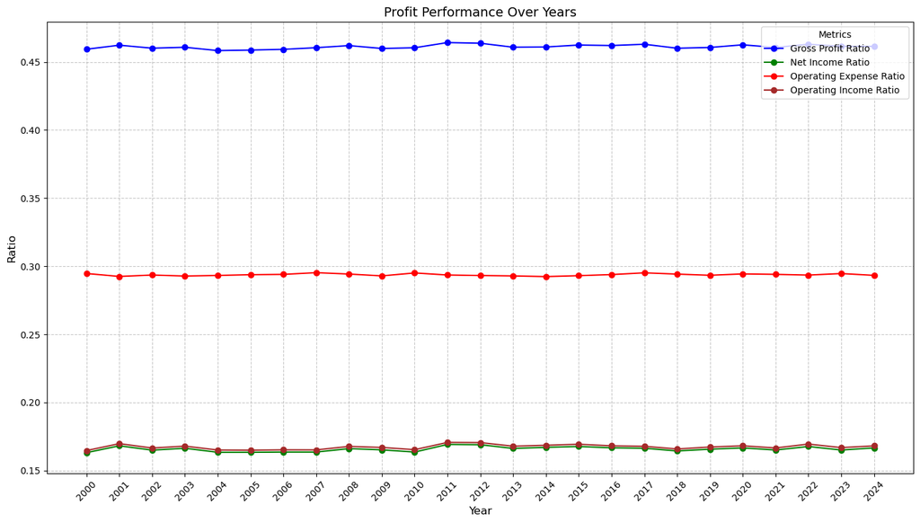

```python
# Filter data for the necessary columns and ensure it's sorted by Year
ratios_df = merged_df[['Year', 'Gross Profit Ratio', 'Net Income Ratio', 'Operating Income Ratio', 'Operating Expense Ratio']].groupby('Year').mean().reset_index()

# Create a line chart
plt.figure(figsize=(14, 8))

# Plot each ratio
plt.plot(ratios_df['Year'], ratios_df['Gross Profit Ratio'], marker='o', label='Gross Profit Ratio', color='blue')
plt.plot(ratios_df['Year'], ratios_df['Net Income Ratio'], marker='o', label='Net Income Ratio', color='green')
plt.plot(ratios_df['Year'], ratios_df['Operating Expense Ratio'], marker='o', label='Operating Expense Ratio', color='red')
plt.plot(ratios_df['Year'], ratios_df['Operating Income Ratio'], marker='o', label='Operating Income Ratio', color='brown')

# Chart title and labels
plt.title('Profit Performance Over Years', fontsize=14)
plt.xlabel('Year', fontsize=12)
plt.ylabel('Ratio', fontsize=12)

# Grid, legend, and layout adjustments
plt.grid(True, linestyle='--', alpha=0.7)
plt.legend(title='Metrics', fontsize=10)
plt.xticks(ratios_df['Year'], rotation=45)

# Display the chart
plt.tight_layout()
plt.show()
```

Gross Profit Ratio is consistently the highest, above Operating Expense Ratio and Net Income Ratio. This suggests stability in both profitability and expenditure relative to revenue across the years.

Operating Income Ratio also mirrors Net Income Ratio, which could indicate either minimal debt (so the company's profit from its operations is almost entirely contributing to net income without influence from interest expense) or low operating margins (lack diversified income streams).

It is expected that Net Income Ratio is the lowest because it accounts for additional expenses which reduce Net Income.

### Checking Interest Expense

To investigate whether most companies have minimal debt, we can check whether interest expense is low relative to the operating income.

If it is low, then it suggests minimal debt. If it is high, then debt could be significant.

```python
merged_df['Interest Coverage Ratio'] = merged_df['Operating Income'] / merged_df['Interest Expense']

# Group by 'Stock' and calculate the average Interest Coverage Ratio for each company
company_debt_data = merged_df.groupby('Stock')['Interest Coverage Ratio'].mean().reset_index()

# Classify companies based on Interest Coverage Ratio thresholds
high_debt_companies = company_debt_data[company_debt_data['Interest Coverage Ratio'] < 1]
moderate_debt_companies = company_debt_data[(company_debt_data['Interest Coverage Ratio'] >= 1) &
                                            (company_debt_data['Interest Coverage Ratio'] <= 2)]
low_debt_companies = company_debt_data[company_debt_data['Interest Coverage Ratio'] > 2]
```

```python
print(f"High Debt Companies: {len(high_debt_companies)}")
print(f"Moderate Debt Companies: {len(moderate_debt_companies)}")
print(f"Low Debt Companies: {len(low_debt_companies)}")
```

```
High Debt Companies: 0
Moderate Debt Companies: 0
Low Debt Companies: 4001
```

All companies in the dataset have high operating income relative to interest expense, meaning low debt.

Next, we will find out the distribution of operating income ratios across companies.

### Checking Operating Income Ratio

```python
# Group by 'Stock' and calculate the average Operating Income Ratio for each company
company_margin_data = merged_df.groupby('Stock')['Operating Income Ratio'].mean().reset_index()

# Classify companies based on Operating Income Ratio thresholds
high_margin_companies = company_margin_data[company_margin_data['Operating Income Ratio'] > 0.2]
moderate_margin_companies = company_margin_data[(company_margin_data['Operating Income Ratio'] >= 0.1) &
                                                (company_margin_data['Operating Income Ratio'] <= 0.2)]
low_margin_companies = company_margin_data[company_margin_data['Operating Income Ratio'] < 0.1]
```

```python
# Print the count of companies in each category
print(f"High Margin Companies: {len(high_margin_companies)}")
print(f"Moderate Margin Companies: {len(moderate_margin_companies)}")
print(f"Low Margin Companies: {len(low_margin_companies)}")
```

```
High Margin Companies: 179
Moderate Margin Companies: 3821
Low Margin Companies: 1
```

Most companies operate with moderate margin, while only a small percentage have high margins.

Companies generating moderate margins could benefit from increasing sales volume such as launching new products and services.

# 4. Analyzing Expenses

### Expense Type Breakdown

We are interested in the expense type distribution (Cost of Revenue, Operating Expenses, Depreciation & Amortization) to observe how they compare across the years.

Cost of Revenue = Revenue - Gross Profit

Operating Expenses = Gross Profit - Operating Income

Depreciation & Amortization = EBITDA - Operating Income

Since all companies from the dataset do not suffer from high debt, all of their net income comes from core business operations and not from financing. Hence, Interest Expense is not included.

```python
# Calculate proportions of each category
expense_proportions = merged_df.groupby('Year')[['Cost of Revenue', 'Operating Expenses', 'Depreciation & Amortization']].sum()
expense_proportions['Total'] = expense_proportions.sum(axis=1)
expense_proportions['Cost of Revenue %'] = expense_proportions['Cost of Revenue'] / expense_proportions['Total'] * 100
expense_proportions['Operating Expenses %'] = expense_proportions['Operating Expenses'] / expense_proportions['Total'] * 100
expense_proportions['Depreciation & Amortization %'] = expense_proportions['Depreciation & Amortization'] / expense_proportions['Total'] * 100

expense_proportions
```

| Year | Cost of Revenue | Operating Expenses | Depreciation & Amortization | Total | Cost of Revenue % | Operating Expenses % | Depreciation & Amortization % |
| --- | --- | --- | --- | --- | --- | --- | --- |
| 2000 | 2.163134e+12 | 1.183981e+12 | 1.855391e+10 | 3.365669e+12 | 64.270553 | 35.178178 | 0.551269 |
| 2001 | 2.167840e+12 | 1.178526e+12 | 1.852294e+10 | 3.364889e+12 | 64.425319 | 35.024204 | 0.550477 |
| 2002 | 2.176929e+12 | 1.179764e+12 | 1.817194e+10 | 3.374865e+12 | 64.504180 | 34.957370 | 0.538449 |
| 2003 | 2.205066e+12 | 1.197573e+12 | 1.849875e+10 | 3.421137e+12 | 64.454169 | 35.005112 | 0.540719 |
| 2004 | 2.177935e+12 | 1.178760e+12 | 1.864100e+10 | 3.375336e+12 | 64.524986 | 34.922743 | 0.552271 |
| 2005 | 2.214372e+12 | 1.201568e+12 | 1.870199e+10 | 3.434642e+12 | 64.471699 | 34.983791 | 0.544511 |
| 2006 | 2.162362e+12 | 1.180070e+12 | 1.842938e+10 | 3.360861e+12 | 64.339512 | 35.112135 | 0.548353 |
| 2007 | 2.138076e+12 | 1.168179e+12 | 1.820901e+10 | 3.324464e+12 | 64.313408 | 35.138865 | 0.547728 |
| 2008 | 2.172339e+12 | 1.188633e+12 | 1.863652e+10 | 3.379609e+12 | 64.277830 | 35.170730 | 0.551440 |
| 2009 | 2.133415e+12 | 1.149567e+12 | 1.844964e+10 | 3.301431e+12 | 64.620909 | 34.820253 | 0.558838 |
| 2010 | 2.181507e+12 | 1.173044e+12 | 1.851494e+10 | 3.373067e+12 | 64.674302 | 34.776793 | 0.548905 |
| 2011 | 2.207875e+12 | 1.191619e+12 | 1.846672e+10 | 3.417960e+12 | 64.596273 | 34.863442 | 0.540285 |
| 2012 | 2.214276e+12 | 1.189608e+12 | 1.849884e+10 | 3.422383e+12 | 64.699838 | 34.759637 | 0.540525 |
| 2013 | 2.189084e+12 | 1.170548e+12 | 1.817267e+10 | 3.377805e+12 | 64.807892 | 34.654106 | 0.538002 |
| 2014 | 2.242374e+12 | 1.193202e+12 | 1.874547e+10 | 3.454322e+12 | 64.915022 | 34.542311 | 0.542667 |
| 2015 | 2.133410e+12 | 1.148503e+12 | 1.833444e+10 | 3.300248e+12 | 64.643931 | 34.800522 | 0.555547 |
| 2016 | 2.205586e+12 | 1.191571e+12 | 1.850807e+10 | 3.415666e+12 | 64.572662 | 34.885480 | 0.541858 |
| 2017 | 2.233387e+12 | 1.209100e+12 | 1.851720e+10 | 3.461004e+12 | 64.530020 | 34.934957 | 0.535024 |
| 2018 | 2.210547e+12 | 1.182573e+12 | 1.824408e+10 | 3.411364e+12 | 64.799493 | 34.665704 | 0.534803 |
| 2019 | 2.177697e+12 | 1.159636e+12 | 1.838613e+10 | 3.355719e+12 | 64.895084 | 34.557012 | 0.547904 |
| 2020 | 2.187075e+12 | 1.183140e+12 | 1.846137e+10 | 3.388676e+12 | 64.540686 | 34.914518 | 0.544796 |
| 2021 | 2.178433e+12 | 1.186393e+12 | 1.849268e+10 | 3.383318e+12 | 64.387456 | 35.065960 | 0.546584 |
| 2022 | 4.256775e+12 | 2.326328e+12 | 3.679623e+10 | 6.619899e+12 | 64.302720 | 35.141437 | 0.555843 |
| 2023 | 4.415360e+12 | 2.410039e+12 | 3.679441e+10 | 6.862193e+12 | 64.343275 | 35.120535 | 0.536190 |
| 2024 | 2.191777e+12 | 1.192527e+12 | 1.829679e+10 | 3.402601e+12 | 64.414756 | 35.047514 | 0.537729 |

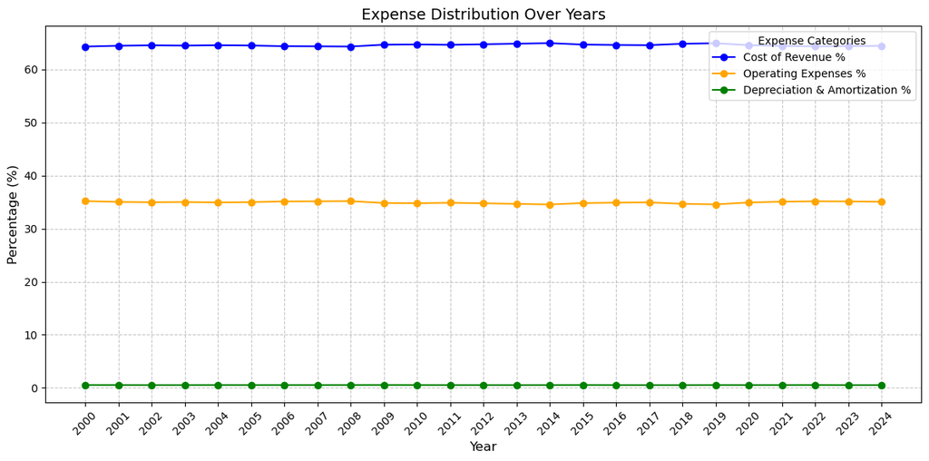

```python
# Prepare the data for plotting
years = expense_proportions.index

plt.figure(figsize=(12, 6))

# Plot each category as a line
plt.plot(years, expense_proportions['Cost of Revenue %'], marker='o', label='Cost of Revenue %', color='blue')
plt.plot(years, expense_proportions['Operating Expenses %'], marker='o', label='Operating Expenses %', color='orange')
plt.plot(years, expense_proportions['Depreciation & Amortization %'], marker='o', label='Depreciation & Amortization %', color='green')

# Add title and labels
plt.title('Expense Distribution Over Years', fontsize=14)
plt.xlabel('Year', fontsize=12)
plt.ylabel('Percentage (%)', fontsize=12)
plt.xticks(years, rotation=45)
plt.legend(title='Expense Categories', fontsize=10)

# Add grid for better readability
plt.grid(True, linestyle='--', alpha=0.7)

# Display the chart
plt.tight_layout()
plt.show()
```

Cost of Revenue is consistently higher than Operating Expenses and Depreciation & Amortization. This means that production & procurement costs (Cost of Revenue) are the most significant expense besides admin, marketing and general expenses (Operating Expenses).

The low D&A also suggests that these companies do not invest in assets that are vulnerable to depreciation.

### Gross Profit vs Cost of Revenue as a Proportion of Revenue

Since Cost of Revenue + Gross Profit = Revenue, it is useful to see whether the gross profit margin is healthy versus the cost of revenue.

```python
mean_expense_proportions = merged_df.groupby('Year')[['Revenue', 'Gross Profit', 'Cost of Revenue']].mean()
mean_expense_proportions = mean_expense_proportions.rename(columns={
    'Revenue': 'Average Revenue',
    'Gross Profit': 'Average Gross Profit',
    'Cost of Revenue': 'Average Cost of Revenue'
})
mean_expense_proportions['Average Gross Profit (Proportion of Revenue)'] = mean_expense_proportions['Average Gross Profit'] / mean_expense_proportions['Average Revenue']
mean_expense_proportions['Average Cost of Revenue (Proportion of Revenue)'] = mean_expense_proportions['Average Cost of Revenue'] / mean_expense_proportions['Average Revenue']

mean_expense_proportions
```

| Year | Average Revenue | Average Gross Profit | Average Cost of Revenue | Average Gross Profit (Proportion of Revenue) | Average Cost of Revenue (Proportion of Revenue) |
| --- | --- | --- | --- | --- | --- |
| 2000 | 1.093991e+09 | 5.031918e+08 | 5.905363e+08 | 0.459960 | 0.539800 |
| 2001 | 1.096365e+09 | 5.079899e+08 | 5.913367e+08 | 0.463340 | 0.539361 |
| 2002 | 1.110405e+09 | 5.096683e+08 | 6.005322e+08 | 0.458993 | 0.540823 |
| 2003 | 1.113631e+09 | 5.133103e+08 | 6.001811e+08 | 0.460934 | 0.538941 |
| 2004 | 1.098549e+09 | 5.041535e+08 | 5.953896e+08 | 0.458927 | 0.541978 |
| 2005 | 1.113106e+09 | 5.107879e+08 | 6.032067e+08 | 0.458885 | 0.541913 |
| 2006 | 1.097552e+09 | 5.027776e+08 | 5.940554e+08 | 0.458090 | 0.541255 |
| 2007 | 1.097033e+09 | 5.066655e+08 | 5.914456e+08 | 0.461851 | 0.539132 |
| 2008 | 1.104291e+09 | 5.094367e+08 | 5.945099e+08 | 0.461325 | 0.538363 |
| 2009 | 1.080115e+09 | 4.936902e+08 | 5.864251e+08 | 0.457072 | 0.542928 |
| 2010 | 1.084823e+09 | 4.982963e+08 | 5.862691e+08 | 0.459334 | 0.540429 |
| 2011 | 1.109043e+09 | 5.149831e+08 | 5.943136e+08 | 0.464349 | 0.535880 |
| 2012 | 1.115974e+09 | 5.172222e+08 | 5.991008e+08 | 0.463472 | 0.536841 |
| 2013 | 1.102382e+09 | 5.075426e+08 | 5.951832e+08 | 0.460405 | 0.539907 |
| 2014 | 1.105658e+09 | 5.088282e+08 | 5.963760e+08 | 0.460204 | 0.539386 |
| 2015 | 1.080353e+09 | 5.004468e+08 | 5.797310e+08 | 0.463225 | 0.536613 |
| 2016 | 1.107210e+09 | 5.113505e+08 | 5.962656e+08 | 0.461837 | 0.538530 |
| 2017 | 1.113136e+09 | 5.149607e+08 | 5.990844e+08 | 0.462621 | 0.538195 |
| 2018 | 1.107473e+09 | 5.096577e+08 | 5.982535e+08 | 0.460199 | 0.540197 |
| 2019 | 1.094703e+09 | 5.037042e+08 | 5.904818e+08 | 0.460129 | 0.539399 |
| 2020 | 1.102034e+09 | 5.105955e+08 | 5.907819e+08 | 0.463321 | 0.536083 |
| 2021 | 1.115652e+09 | 5.138746e+08 | 6.017770e+08 | 0.460605 | 0.539395 |
| 2022 | 1.084263e+09 | 5.013029e+08 | 5.829602e+08 | 0.462344 | 0.537656 |
| 2023 | 1.117092e+09 | 5.143951e+08 | 6.026972e+08 | 0.460477 | 0.539523 |
| 2024 | 1.113483e+09 | 5.131606e+08 | 6.003224e+08 | 0.460861 | 0.539139 |

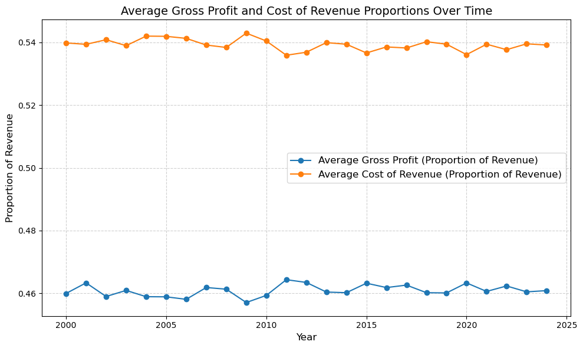

```python
plt.figure(figsize=(10, 6))

plt.plot(mean_expense_proportions.index,
         mean_expense_proportions['Average Gross Profit (Proportion of Revenue)'],
         label='Average Gross Profit (Proportion of Revenue)',
         marker='o')
plt.plot(mean_expense_proportions.index,
         mean_expense_proportions['Average Cost of Revenue (Proportion of Revenue)'],
         label='Average Cost of Revenue (Proportion of Revenue)',
         marker='o')

plt.title('Average Gross Profit and Cost of Revenue Proportions Over Time', fontsize=14)
plt.xlabel('Year', fontsize=12)
plt.ylabel('Proportion of Revenue', fontsize=12)

plt.legend(fontsize=12)
plt.grid(visible=True, linestyle='--', alpha=0.6)

plt.tight_layout()
plt.show()
```

The stable Cost of Revenue means that companies have not significantly reduced their cost base.

Companies can look for other opportunities to reduce production costs or improve resource allocation to lower Cost of Revenue, while explore other revenue-generating strategies to push Gross Profit Ratio even higher.

```python
# merged_df.to_csv('merged_df_v3.csv', index=False)
```